# Code_Omer_Zinman And Eran_Schlezinger

**Table of contents**

- **Model 1**
  - Variable Manipulation
  - Model Manipulation
  - Model Evaluation
  - Conclusion
  - future steps and recommendations
- **Model 3**
  - Variable Manipulation
  - Model Manipulation
  - Model Evaluation
  - In conclusion
- **Model 4**
  - Variable Manipulation
  - Model Manipulation
  - Model Evaluation
  - Conclusion
    - Precision:
    - Recall:
    - F1-Score:
    - Overall Metrics:
  - Recommendations
- **Model 5**
  - Variable Manipulation
  - Model Manipulation
  - Model Evaluation
  - Conclusion
  - Recommendations

```python
import pandas as pd
import numpy as np
import seaborn as sns
import matplotlib.pyplot as plt
from sklearn.linear_model import LinearRegression, LogisticRegression
from sklearn.tree import DecisionTreeClassifier, plot_tree
from sklearn.preprocessing import StandardScaler
from sklearn.neighbors import KNeighborsClassifier
from sklearn.metrics import r2_score, accuracy_score
from sklearn.metrics import confusion_matrix, classification_report
from sklearn.model_selection import train_test_split
```

```python
path_to_csv = 'https://raw.githubusercontent.com/omer7642/ManagementOperationsFinalProject/main/Data/brain_stroke.csv'
```

# **Model 1**

In this model, the features are:

- avg_glucose_level
- bmi
- age

We need to predict gender  
the model uses Decision tree

```python
#load the dataset
df = pd.read_csv(path_to_csv)
df.head()
```

|  | gender | age | hypertension | heart_disease | ever_married | work_type | Residence_type | avg_glucose_level | bmi | smoking_status | stroke |
| --- | --- | --- | --- | --- | --- | --- | --- | --- | --- | --- | --- |
| 0 | Male | 67.0 | 0 | 1 | Yes | Private | Urban | 228.69 | 36.6 | formerly smoked | 1 |
| 1 | Male | 80.0 | 0 | 1 | Yes | Private | Rural | 105.92 | 32.5 | never smoked | 1 |
| 2 | Female | 49.0 | 0 | 0 | Yes | Private | Urban | 171.23 | 34.4 | smokes | 1 |
| 3 | Female | 79.0 | 1 | 0 | Yes | Self-employed | Rural | 174.12 | 24.0 | never smoked | 1 |
| 4 | Male | 81.0 | 0 | 0 | Yes | Private | Urban | 186.21 | 29.0 | formerly smoked | 1 |

## Variable Manipulation

Decision Tree's features **must** be numerical (because of the fitting function). However we learned that all variables need to be categorical in a Decision Tree.  
for that reason we need to change non-categorical variables into categorical ones, represented by a numeric value.

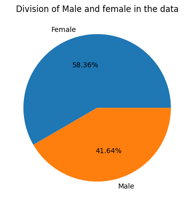

```python
#Since gender is already a categorical variable, we will visualize how it divides
count = df['gender'].value_counts()
count.plot(kind='pie', autopct='%1.2f%%', color='skyblue')
plt.title("Division of Male and female in the data")
plt.ylabel('')
plt.show()
```

We can see we have more females than males.

```python
#since age is a number, and decision tree works on categories, we will need to convert numerical variable to categories
def get_age_category(age):
    if age < 18:
        return 0
    elif age < 35:
        return 1
    elif age < 50:
        return 2
    elif age < 65:
        return 3
    else:
        return 4
#apply those categories to the age variable
df['age']=df['age'].apply(get_age_category)

df.head()
```

|  | gender | age | hypertension | heart_disease | ever_married | work_type | Residence_type | avg_glucose_level | bmi | smoking_status | stroke |
| --- | --- | --- | --- | --- | --- | --- | --- | --- | --- | --- | --- |
| 0 | Male | 4 | 0 | 1 | Yes | Private | Urban | 228.69 | 36.6 | formerly smoked | 1 |
| 1 | Male | 4 | 0 | 1 | Yes | Private | Rural | 105.92 | 32.5 | never smoked | 1 |
| 2 | Female | 2 | 0 | 0 | Yes | Private | Urban | 171.23 | 34.4 | smokes | 1 |
| 3 | Female | 4 | 1 | 0 | Yes | Self-employed | Rural | 174.12 | 24.0 | never smoked | 1 |
| 4 | Male | 4 | 0 | 0 | Yes | Private | Urban | 186.21 | 29.0 | formerly smoked | 1 |

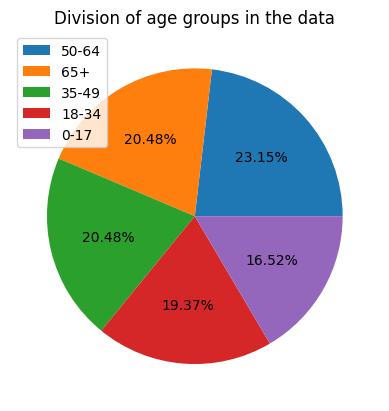

```python
# We will use a temporary series and map the needed age
s_temp = df['age'].copy()
s_temp = s_temp.map({0: "0-17", 1: "18-34", 2: "35-49", 3: "50-64", 4: "65+"})
s_temp.value_counts().plot(kind='pie', autopct='%1.2f%%', color='skyblue', labels=None, ylabel='', title='Division of age groups in the data', legend=True)
```

We can see age groups divide pretty much equally (~20%) for each age group.

```python
#since bmi is a numerical variable we need to do the same
def get_bmi_category(bmi):
    if bmi < 18.5:
        return 0
    elif bmi < 25:
        return 1
    elif bmi < 29.9:
        return 2
    elif bmi < 34.5:
        return 3
    else:
        return 4

df['bmi'] = df['bmi'].apply(get_bmi_category)
df.head()
```

|  | gender | age | hypertension | heart_disease | ever_married | work_type | Residence_type | avg_glucose_level | bmi | smoking_status | stroke |
| --- | --- | --- | --- | --- | --- | --- | --- | --- | --- | --- | --- |
| 0 | Male | 4 | 0 | 1 | Yes | Private | Urban | 228.69 | 4 | formerly smoked | 1 |
| 1 | Male | 4 | 0 | 1 | Yes | Private | Rural | 105.92 | 3 | never smoked | 1 |
| 2 | Female | 2 | 0 | 0 | Yes | Private | Urban | 171.23 | 3 | smokes | 1 |
| 3 | Female | 4 | 1 | 0 | Yes | Self-employed | Rural | 174.12 | 1 | never smoked | 1 |
| 4 | Male | 4 | 0 | 0 | Yes | Private | Urban | 186.21 | 2 | formerly smoked | 1 |

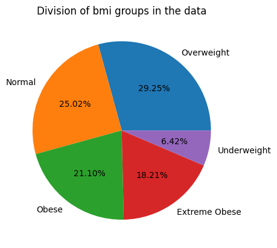

```python
## we will chart and represent the bmi based on information we took for categorization
s_temp = df['bmi'].copy()
s_temp = s_temp.map({0: "Underweight", 1: "Normal", 2: "Overweight", 3: "Obese", 4: "Extreme Obese"})
s_temp.value_counts().plot(kind='pie', autopct='%1.2f%%', color='skyblue', ylabel='', title='Division of bmi groups in the data')
```

We can clearly see that most people have normal to high weight-height ratio.  
The majority of the patients are overweight (29.25%), while only few (6.42%) are underweight.

```python
#we do the same for avg_glucose_level (shortened as agl)
# print(df['avg_glucose_level'].max())
# print(df['avg_glucose_level'].min())

def get_agl_category(agl):
    if agl < 100:
        return 0
    elif agl < 150:
        return 1
    elif agl < 200:
        return 2
    elif agl < 250:
        return 3
    else:
        return 4

df['avg_glucose_level'] = df['avg_glucose_level'].apply(get_agl_category)
df.head()
```

|  | gender | age | hypertension | heart_disease | ever_married | work_type | Residence_type | avg_glucose_level | bmi | smoking_status | stroke |
| --- | --- | --- | --- | --- | --- | --- | --- | --- | --- | --- | --- |
| 0 | Male | 4 | 0 | 1 | Yes | Private | Urban | 3 | 4 | formerly smoked | 1 |
| 1 | Male | 4 | 0 | 1 | Yes | Private | Rural | 1 | 3 | never smoked | 1 |
| 2 | Female | 2 | 0 | 0 | Yes | Private | Urban | 2 | 3 | smokes | 1 |
| 3 | Female | 4 | 1 | 0 | Yes | Self-employed | Rural | 2 | 1 | never smoked | 1 |
| 4 | Male | 4 | 0 | 0 | Yes | Private | Urban | 2 | 2 | formerly smoked | 1 |

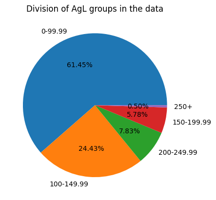

```python
# Representing AgL in a pie chart (since it's divided to categories)
## we will chart and represent the bmi based on information we took for categorization
s_temp = df['avg_glucose_level'].copy()
s_temp = s_temp.map({0: "0-99.99", 1: "100-149.99", 2: "150-199.99", 3: "200-249.99", 4: "250+"})
s_temp.value_counts().plot(kind='pie', autopct='%1.2f%%', color='skyblue', ylabel='', title='Division of AgL groups in the data')
```

We can see most patients (61.45%) have normal AgL (up to 100 mg/dL)  
However, some have somewhat high AgL , and few have extremely high values.

## Model Manipulation

Now that all non-categorical variables are categorized, we will need to train the model and fit it.

```python
#split to train and test data
X = df[['age', 'bmi','avg_glucose_level']]
y = df['gender']
X_train, X_test, y_train, y_test = train_test_split(X, y, test_size=0.28, random_state=42)
```

```python
#train the model
model = DecisionTreeClassifier(max_depth=3)
model.fit(X_train, y_train)
```

```
DecisionTreeClassifier(max_depth=3)
```

## Model Evaluation

```python
#prediction and prediction accuracy
y_pred = model.predict(X_test)
accuracy = accuracy_score(y_test, y_pred)
print("The model accuracy is: ", round(accuracy * 100, 2), '%')
```

```
The model accuracy is:  58.71 %
```

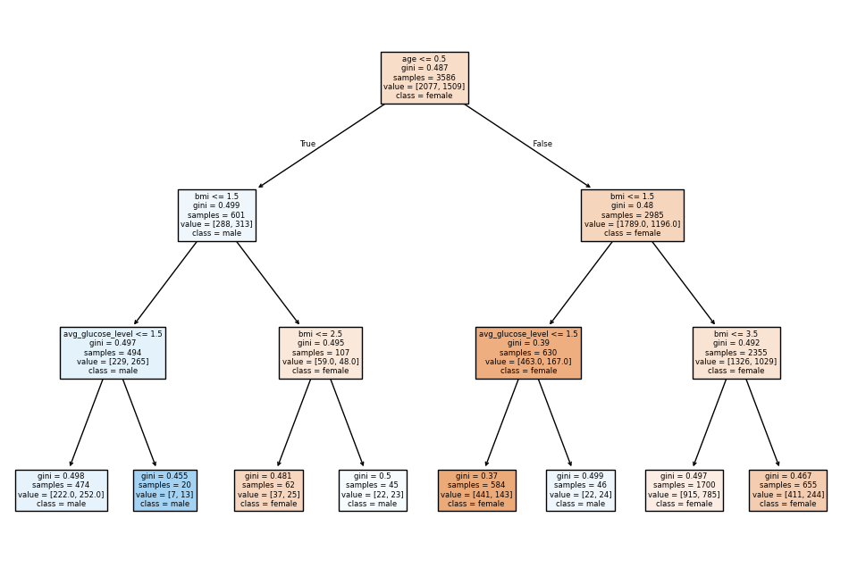

```python
#Visualize the model
plt.figure(figsize=(12,8))
plot_tree(model, filled=True, feature_names=['age', 'bmi', 'avg_glucose_level'], class_names=['female', 'male'])
plt.show()
```

From this we can see:

- Age is the most important feature for the first split, suggesting that it plays a critical role in distinguishing between male and female in this dataset.
- BMI and avg_glucose_level are secondary factors that further refine the classification.
- The decision tree suggests that certain combinations of these features are more likely to be associated with one gender than the other.
- The overall classification accuracy would likely depend on the depth and purity of the leaf nodes, as indicated by the Gini index.

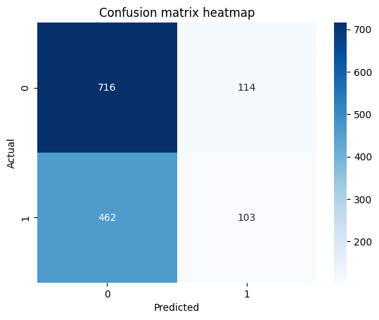

```python
cm = confusion_matrix(y_test,y_pred)
sns.heatmap(cm, annot=True, cmap='Blues', fmt='g')
plt.xlabel('Predicted')
plt.ylabel('Actual')
plt.title('Confusion matrix heatmap')
plt.show()
```

```python
print('classification report:\n',classification_report(y_test, y_pred))
```

```
classification report:
               precision    recall  f1-score   support

      Female       0.61      0.86      0.71       830
        Male       0.47      0.18      0.26       565

    accuracy                           0.59      1395
   macro avg       0.54      0.52      0.49      1395
weighted avg       0.55      0.59      0.53      1395
```

## Conclusion

- The decision tree model has a significant bias towards predicting the female class, which is reflected in the higher recall and F1-score for females compared to males.
- The low recall for males is a critical issue, as it suggests that the model is failing to identify a large number of male instances.
- The overall accuracy of 59% indicates that the model could be improved, especially in terms of balancing the performance between the two classes.

## future steps and recommendations

- Consider Using a Different Model: Decision trees are prone to overfitting and may not capture complex relationships in the data. You might consider trying more advanced models like Random Forests, or even neural networks, which may handle the class imbalance better.
- Address Class Imbalance: You might want to explore techniques such as oversampling the minority class (males), undersampling the majority class (females), or using other techniques.
- Parameter Tuning: Adjusting parameters such as the depth of the tree, minimum samples per leaf, or even using cost-sensitive learning could improve the model's performance, particularly for the male class.

# **Model 3**

The features are:

- smoking_status
- avg_glucose_levelmi

We aim to predict **ever_married** and we use **Linear regression** to achieve this

```python
# load the datasets
df=pd.read_csv(path_to_csv)
df.head()
```

|  | gender | age | hypertension | heart_disease | ever_married | work_type | Residence_type | avg_glucose_level | bmi | smoking_status | stroke |
| --- | --- | --- | --- | --- | --- | --- | --- | --- | --- | --- | --- |
| 0 | Male | 67.0 | 0 | 1 | Yes | Private | Urban | 228.69 | 36.6 | formerly smoked | 1 |
| 1 | Male | 80.0 | 0 | 1 | Yes | Private | Rural | 105.92 | 32.5 | never smoked | 1 |
| 2 | Female | 49.0 | 0 | 0 | Yes | Private | Urban | 171.23 | 34.4 | smokes | 1 |
| 3 | Female | 79.0 | 1 | 0 | Yes | Self-employed | Rural | 174.12 | 24.0 | never smoked | 1 |
| 4 | Male | 81.0 | 0 | 0 | Yes | Private | Urban | 186.21 | 29.0 | formerly smoked | 1 |

## Variable Manipulation

Since we use linear regression, the features need to be numerical.  
However, smoking_status and ever_married are cateforical variables, meaning we wil lose some value when mapping them.

```python
#since smoking_status is a non-numerical field, we will need to get all his possible values
df['smoking_status'].unique()
```

```
array(['formerly smoked', 'never smoked', 'smokes', 'Unknown'],
      dtype=object)
```

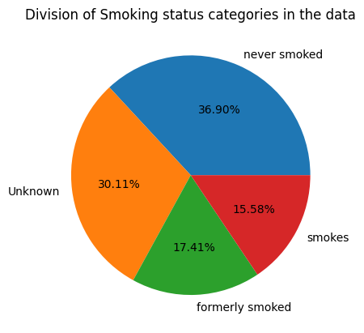

```python
# We will chart the variable in a pie chart like in Model 1
s_temp = df['smoking_status'].copy()
s_temp.value_counts().plot(kind='pie', autopct='%1.2f%%', color='skyblue', ylabel='', title='Division of Smoking status categories in the data')
```

The smoking status categories show a significant portion (30.11%) as "Unknown," which may impact the predictive power of this feature.

The "Never smoked" category dominates the data, which might imply a potential correlation with the marital status.

```python
#same goes with ever_married
df['ever_married'].unique()
```

```
array(['Yes', 'No'], dtype=object)
```

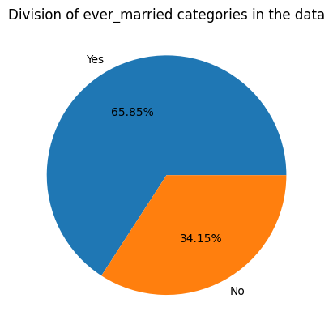

```python
#making a pie chart of ever_married status
s_temp = df['ever_married'].copy()
s_temp.value_counts().plot(kind='pie', autopct='%1.2f%%', color='skyblue', ylabel='', title='Division of ever_married categories in the data')
```

The majority of the data points fall under the "Yes" category, indicating most individuals in the dataset are married.

This imbalance might affect the linear regression model's accuracy and its ability to generalize.

```python
#Check to see if any value of avg_glucose_level is NaN (Not a number), to know if I need to deal with it
np.isnan(df['avg_glucose_level']).any()
```

```
np.False_
```

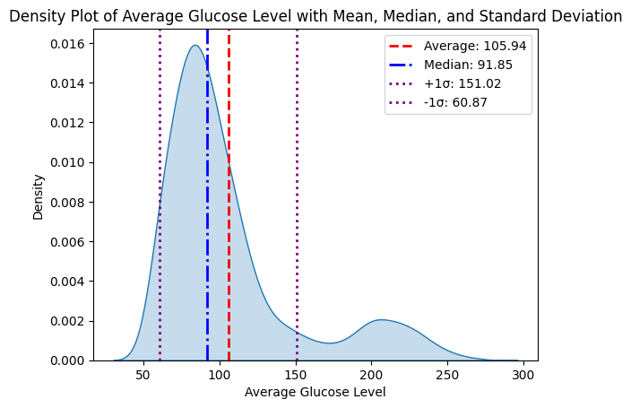

```python
#since AgL in this model is numerical, we will plot him a density chart to map its values


sns.kdeplot(df['avg_glucose_level'], fill=True)

# Calculate the mean, median, and standard deviation of the series
mean_value = df['avg_glucose_level'].mean()
median_value = df['avg_glucose_level'].median()
std_dev = df['avg_glucose_level'].std()

# Add a vertical line for the average
plt.axvline(mean_value, color='red', linestyle='--', linewidth=2, label=f'Average: {mean_value:.2f}')

# Add a vertical line for the median
plt.axvline(median_value, color='blue', linestyle='-.', linewidth=2, label=f'Median: {median_value:.2f}')

# Add vertical lines for ±1 standard deviation
plt.axvline(mean_value + std_dev, color='purple', linestyle=':', linewidth=2, label=f'+1σ: {mean_value + std_dev:.2f}')
plt.axvline(mean_value - std_dev, color='purple', linestyle=':', linewidth=2, label=f'-1σ: {mean_value - std_dev:.2f}')

# Adding labels, title, and legend
plt.xlabel('Average Glucose Level')
plt.ylabel('Density')
plt.title('Density Plot of Average Glucose Level with Mean, Median, and Standard Deviation')
plt.legend()

# Show the plot
plt.show()
```

The average glucose levels have a wide range, but the majority of the data is clustered around lower glucose levels.

The data shows a right-skewed distribution, indicating a minority of the population with higher glucose levels,

which might be associated with lifestyle factors including smoking status or marital status.

```python
# Map categorical variables to values
df['smoking_status'] = df['smoking_status'].map({'Unknown': 0, 'never smoked': 1, 'formerly smoked': 2, 'smokes': 3})
df['ever_married'] = df['ever_married'].map({'No': 0, 'Yes': 1})
df.head()
```

|  | gender | age | hypertension | heart_disease | ever_married | work_type | Residence_type | avg_glucose_level | bmi | smoking_status | stroke |
| --- | --- | --- | --- | --- | --- | --- | --- | --- | --- | --- | --- |
| 0 | Male | 67.0 | 0 | 1 | 1 | Private | Urban | 228.69 | 36.6 | 2 | 1 |
| 1 | Male | 80.0 | 0 | 1 | 1 | Private | Rural | 105.92 | 32.5 | 1 | 1 |
| 2 | Female | 49.0 | 0 | 0 | 1 | Private | Urban | 171.23 | 34.4 | 3 | 1 |
| 3 | Female | 79.0 | 1 | 0 | 1 | Self-employed | Rural | 174.12 | 24.0 | 1 | 1 |
| 4 | Male | 81.0 | 0 | 0 | 1 | Private | Urban | 186.21 | 29.0 | 2 | 1 |

## Model Manipulation

For our task we use linear regression.

```python
#Define the features and output
X=df[['avg_glucose_level','smoking_status']]
y=df['ever_married']
```

```python
# Split to train/test based on assignment
X_train,X_test,y_train,y_test=train_test_split(X,y,test_size=0.26,random_state=0)
```

```python
# Creating and fit the model
model=LinearRegression().fit(X,y)
model
```

```
LinearRegression()
```

## Model Evaluation

```python
#find the model coefficient - the coefficient of each feature X in prediction of Y
model.coef_
```

```
array([0.00135374, 0.12729781])
```

```python
#find the intercept - the value that is not dependent on the features and that is constant
model.intercept_
```

```
np.float64(0.36429792641933856)
```

```python
#prediction of unknown values
y_pred = model.predict(X_test)
y_pred
```

```
array([0.76861714, 0.80845201, 0.46214622, ..., 0.82047321, 0.62672601,
       0.68122757])
```

We can clearly see that y_pred predicts numbers that are not 0 (for 'No') or 1 (for 'yes').  
we will need to round the numbers to get accurate predictions

```python
y_pred = np.around(y_pred)
y_pred
```

```
array([1., 1., 0., ..., 1., 1., 1.])
```

```python
#evaluate the model
accuracy=r2_score(y_test,y_pred)*100
print(f'The accuracy of the model is {round(accuracy, 2)}%')
```

```
The accuracy of the model is -31.2%
```

However, some of the values are taking arbitrary values (those mapped from categorical to numerical values), that's why I will not rely on that.

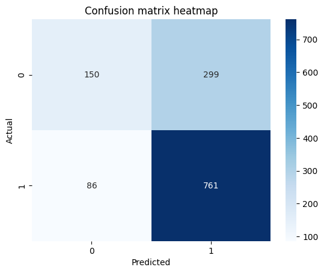

```python
cm = confusion_matrix(y_test,y_pred)
sns.heatmap(cm, annot=True, cmap='Blues', fmt='g')
plt.xlabel('Predicted')
plt.ylabel('Actual')
plt.title('Confusion matrix heatmap')
plt.show()
```

```python
print('classification report:\n',classification_report(y_test, y_pred))
```

```
classification report:
               precision    recall  f1-score   support

           0       0.64      0.33      0.44       449
           1       0.72      0.90      0.80       847

    accuracy                           0.70      1296
   macro avg       0.68      0.62      0.62      1296
weighted avg       0.69      0.70      0.67      1296
```

## In conclusion

- Consider addressing the imbalance in the "ever_married" category or using a different model that handles imbalanced data better.
- Investigate the "Unknown" category in the smoking status feature, as it might introduce noise into the model.
- Explore feature engineering or adding more relevant features to improve the model’s prediction accuracy, as linear regression may not fully capture complex relationships between the features and the target variable.

# **Model 4**

The features are:

- smoking_status
- bmi
- avg_glucose_level
- age

We aim to predict heart_disease and we use Logistic regression to achieve this

```python
# load the datasets
df=pd.read_csv(path_to_csv)
df.head()
```

|  | gender | age | hypertension | heart_disease | ever_married | work_type | Residence_type | avg_glucose_level | bmi | smoking_status | stroke |
| --- | --- | --- | --- | --- | --- | --- | --- | --- | --- | --- | --- |
| 0 | Male | 67.0 | 0 | 1 | Yes | Private | Urban | 228.69 | 36.6 | formerly smoked | 1 |
| 1 | Male | 80.0 | 0 | 1 | Yes | Private | Rural | 105.92 | 32.5 | never smoked | 1 |
| 2 | Female | 49.0 | 0 | 0 | Yes | Private | Urban | 171.23 | 34.4 | smokes | 1 |
| 3 | Female | 79.0 | 1 | 0 | Yes | Self-employed | Rural | 174.12 | 24.0 | never smoked | 1 |
| 4 | Male | 81.0 | 0 | 0 | Yes | Private | Urban | 186.21 | 29.0 | formerly smoked | 1 |

## Variable Manipulation

We map smoking_status and avg_glucose_level in the same way we mapped before, hence no different chart is needed.

However - age, bmi, and heart_disease will need new charts (age and bmi are treated as numerical and heart_disease didn't appear in previous models)

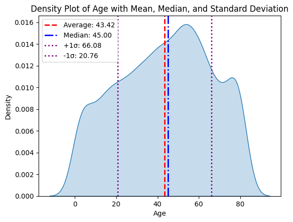

```python
# Same as in previous model, we will plot for age
sns.kdeplot(df['age'], fill=True)

# Calculate the mean, median, and standard deviation of the series
mean_value = df['age'].mean()
median_value = df['age'].median()
std_dev = df['age'].std()

# Add a vertical line for the average
plt.axvline(mean_value, color='red', linestyle='--', linewidth=2, label=f'Average: {mean_value:.2f}')

# Add a vertical line for the median
plt.axvline(median_value, color='blue', linestyle='-.', linewidth=2, label=f'Median: {median_value:.2f}')

# Add vertical lines for ±1 standard deviation
plt.axvline(mean_value + std_dev, color='purple', linestyle=':', linewidth=2, label=f'+1σ: {mean_value + std_dev:.2f}')
plt.axvline(mean_value - std_dev, color='purple', linestyle=':', linewidth=2, label=f'-1σ: {mean_value - std_dev:.2f}')

# Adding labels, title, and legend
plt.xlabel('Age')
plt.ylabel('Density')
plt.title('Density Plot of Age with Mean, Median, and Standard Deviation')
plt.legend()

# Show the plot
plt.show()
```

Age has a relatively broad distribution with the majority of the data falling between 20 and 60 years.

The slight skew towards younger ages could impact model predictions, especially if age is correlated with heart disease incidence.

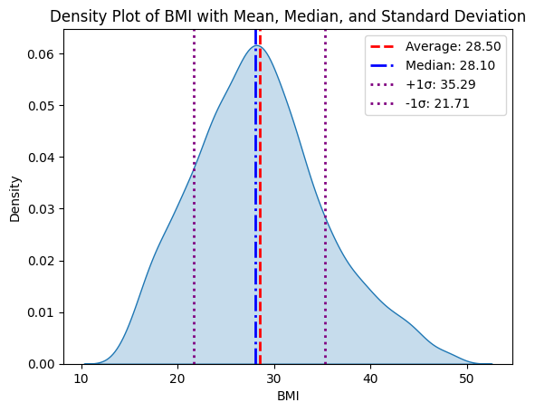

```python
#same with bmi
sns.kdeplot(df['bmi'], fill=True)

# Calculate the mean, median, and standard deviation of the series
mean_value = df['bmi'].mean()
median_value = df['bmi'].median()
std_dev = df['bmi'].std()

# Add a vertical line for the average
plt.axvline(mean_value, color='red', linestyle='--', linewidth=2, label=f'Average: {mean_value:.2f}')

# Add a vertical line for the median
plt.axvline(median_value, color='blue', linestyle='-.', linewidth=2, label=f'Median: {median_value:.2f}')

# Add vertical lines for ±1 standard deviation
plt.axvline(mean_value + std_dev, color='purple', linestyle=':', linewidth=2, label=f'+1σ: {mean_value + std_dev:.2f}')
plt.axvline(mean_value - std_dev, color='purple', linestyle=':', linewidth=2, label=f'-1σ: {mean_value - std_dev:.2f}')

# Adding labels, title, and legend
plt.xlabel('BMI')
plt.ylabel('Density')
plt.title('Density Plot of BMI with Mean, Median, and Standard Deviation')
plt.legend()

# Show the plot
plt.show()
```

The BMI distribution is close to a normal distribution, centered around the average of 28.5. With a standard deviation of about 6.79, it shows that BMI is fairly consistent across the population.

This variable is likely to be informative for the model.

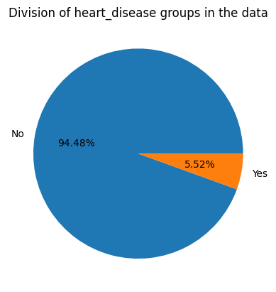

```python
#And same with heart diseases (taken from Model 1)
s_temp = df['heart_disease'].copy()
s_temp = s_temp.map({0: "No", 1: "Yes"})
s_temp.value_counts().plot(kind='pie', autopct='%1.2f%%', color='skyblue', ylabel='', title='Division of heart_disease groups in the data')
```

The heart disease variable is highly imbalanced, with 94.48% of the data indicating no heart disease and only 5.52% indicating the presence of heart disease.

This significant imbalance can be problematic for model training, as the model may become biased towards predicting the majority class (no heart disease), leading to poor performance in detecting the minority class (heart disease).

```python
#like in previous model, map smoking_status to numbers since its a categorical field
df['smoking_status'] = df['smoking_status'].map({'Unknown': 0, 'never smoked': 1, 'formerly smoked': 2, 'smokes': 3})
df.head()
```

|  | gender | age | hypertension | heart_disease | ever_married | work_type | Residence_type | avg_glucose_level | bmi | smoking_status | stroke |
| --- | --- | --- | --- | --- | --- | --- | --- | --- | --- | --- | --- |
| 0 | Male | 67.0 | 0 | 1 | Yes | Private | Urban | 228.69 | 36.6 | 2 | 1 |
| 1 | Male | 80.0 | 0 | 1 | Yes | Private | Rural | 105.92 | 32.5 | 1 | 1 |
| 2 | Female | 49.0 | 0 | 0 | Yes | Private | Urban | 171.23 | 34.4 | 3 | 1 |
| 3 | Female | 79.0 | 1 | 0 | Yes | Self-employed | Rural | 174.12 | 24.0 | 1 | 1 |
| 4 | Male | 81.0 | 0 | 0 | Yes | Private | Urban | 186.21 | 29.0 | 2 | 1 |

```python
#now, check if any of the other fields contain anything that is not a number (NaN)
print('bmi has NaN: ', np.isnan(df['bmi']).any())
print('avg_glucose_level has NaN: ', np.isnan(df['avg_glucose_level']).any())
print('age has NaN: ', np.isnan(df['age']).any())
print('heart_disease has NaN: ', np.isnan(df['heart_disease']).any())
```

```
bmi has NaN:  False
avg_glucose_level has NaN:  False
age has NaN:  False
heart_disease has NaN:  False
```

## Model Manipulation

```python
#select features
X=df[['age','avg_glucose_level', 'smoking_status', 'bmi']]
y=df['heart_disease']
```

```python
#now that we got all information ready, let's split to train/test 76/24
X_train,X_test,y_train,y_test=train_test_split(X,y,test_size=0.24,random_state=20)
```

```python
model = LogisticRegression(max_iter=500)
model.fit(X_train, y_train)
```

```
LogisticRegression(max_iter=500)
```

## Model Evaluation

```python
y_pred= model.predict(X_test)
y_pred
```

```
array([0, 0, 0, ..., 0, 0, 0])
```

```python
np.unique(y_pred)
```

```
array([0])
```

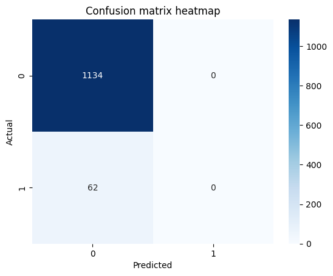

```python
cm = confusion_matrix(y_test,y_pred)
sns.heatmap(cm, annot=True, cmap='Blues', fmt='g')
plt.xlabel('Predicted')
plt.ylabel('Actual')
plt.title('Confusion matrix heatmap')
plt.show()
```

```python
print('classification report:\n',classification_report(y_test, y_pred, zero_division=1))
```

```
classification report:
               precision    recall  f1-score   support

           0       0.95      1.00      0.97      1134
           1       1.00      0.00      0.00        62

    accuracy                           0.95      1196
   macro avg       0.97      0.50      0.49      1196
weighted avg       0.95      0.95      0.92      1196
```

## Conclusion

### Precision:

Class 0 (No Heart Disease): Precision is 0.95, which means that 95% of the instances predicted as "No Heart Disease" are correct. This is a high precision, indicating the model is reliable when it predicts no heart disease.

Class 1 (Heart Disease): Precision is 1.00, meaning every predicted "Heart Disease" instance is correct. However, this metric is somewhat misleading because the recall is 0.00, implying that the model did not actually identify any true heart disease cases.

### Recall:

Class 0 (No Heart Disease): Recall is 1.00, showing that the model correctly identified all instances of no heart disease.

Class 1 (Heart Disease): Recall is 0.00, meaning the model failed to identify any true positive heart disease cases. This is a critical issue, particularly in a medical setting, where missing true cases can have severe consequences.

### F1-Score:

Class 0 (No Heart Disease): The F1-score is 0.97, reflecting a strong balance between precision and recall.

Class 1 (Heart Disease): The F1-score is 0.00, indicating that the model is ineffective at predicting heart disease due to the complete lack of recall.

### Overall Metrics:

Accuracy: The model shows a high accuracy of 0.95, but this is misleading due to the class imbalance. The model is biased towards predicting the majority class (no heart disease).

Macro Average: The macro average F1-score of 0.49 shows that, on average, the model is performing poorly across classes, especially for the minority class.

Weighted Average: The weighted average F1-score of 0.92 heavily favors the majority class, further masking the model's deficiencies in predicting heart disease.

## Recommendations

To enhance the model's ability to predict heart disease, balance the number of cases in each group and consider adjusting the decision point where the model makes its predictions.

Try using different methods or tools that might be better suited for this type of problem. Instead of just looking at overall accuracy,

focus on how well the model identifies heart disease cases. Additionally, look for ways to improve the model by refining the data it uses.

# **Model 5**

In this model, the features are:

- avg_glucose_level
- bmi
- work_type

We aim to predict **hypertension**  
we use **KNN model**

```python
#load the dataset
df=pd.read_csv(path_to_csv)
df.head()
```

|  | gender | age | hypertension | heart_disease | ever_married | work_type | Residence_type | avg_glucose_level | bmi | smoking_status | stroke |
| --- | --- | --- | --- | --- | --- | --- | --- | --- | --- | --- | --- |
| 0 | Male | 67.0 | 0 | 1 | Yes | Private | Urban | 228.69 | 36.6 | formerly smoked | 1 |
| 1 | Male | 80.0 | 0 | 1 | Yes | Private | Rural | 105.92 | 32.5 | never smoked | 1 |
| 2 | Female | 49.0 | 0 | 0 | Yes | Private | Urban | 171.23 | 34.4 | smokes | 1 |
| 3 | Female | 79.0 | 1 | 0 | Yes | Self-employed | Rural | 174.12 | 24.0 | never smoked | 1 |
| 4 | Male | 81.0 | 0 | 0 | Yes | Private | Urban | 186.21 | 29.0 | formerly smoked | 1 |

## Variable Manipulation

Since we use KNN Model we will need to use standardized the features (will happen in the model manipulation) We will draw pie charts of hypertension and work_type

```python
#check unique values of each feature and prediction, for numerical values check the range (min max)
print("avg_glucose_level: \n", 'min: ', df['avg_glucose_level'].min(),  ", " ,'max: ', df['avg_glucose_level'].max(), '\n')
print("bmi: \n", 'min: ', df['bmi'].min(), ", " ,'max: ', df['bmi'].max(), '\n')
print("work_type: \n", df['work_type'].unique(), '\n')
print("hypertension: \n", df['hypertension'].unique(), '\n')
```

```
avg_glucose_level:
 min:  55.12 ,  max:  271.74

bmi:
 min:  14.0 ,  max:  48.9

work_type:
 ['Private' 'Self-employed' 'Govt_job' 'children']

hypertension:
 [0 1]
```

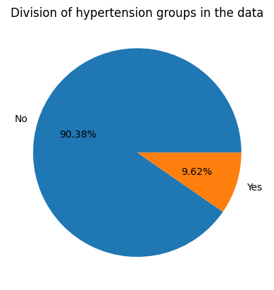

```python
# we will create a pie chart of hypertension and map 0 to No and 1 to Yes
s_temp = df['hypertension'].copy()
s_temp = s_temp.map({0: "No", 1: "Yes"})
s_temp.value_counts().plot(kind='pie', autopct='%1.2f%%', color='skyblue', ylabel='', title='Division of hypertension groups in the data')
```

A large majority of the individuals do not have hypertension (90.38%).

This imbalance likely contributes to the model's difficulty in predicting the minority class (hypertension cases).

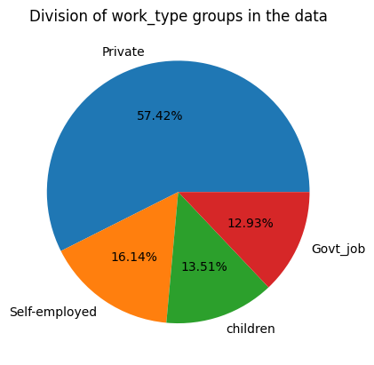

```python
# we will create a pie chart for work_type. there will be no mapping here since we have a categorical variables
s_temp = df['work_type'].copy()
s_temp.value_counts().plot(kind='pie', autopct='%1.2f%%', color='skyblue', ylabel='', title='Division of work_type groups in the data')
```

Work Type Distribution: The majority of the data consists of individuals working in private jobs (57.42%), with smaller proportions for self-employed, government jobs, and children.

This imbalance could influence model performance if certain work types correlate with hypertension.

```python
#we can see work_type has non-numerical values, which means we need to map it to a numerical value to be used in KNN
df['work_type'] = df['work_type'].map({'Private': 3, 'Self-employed': 2, 'Govt_job':1,'children':0})

df.head()
```

|  | gender | age | hypertension | heart_disease | ever_married | work_type | Residence_type | avg_glucose_level | bmi | smoking_status | stroke |
| --- | --- | --- | --- | --- | --- | --- | --- | --- | --- | --- | --- |
| 0 | Male | 67.0 | 0 | 1 | Yes | 3 | Urban | 228.69 | 36.6 | formerly smoked | 1 |
| 1 | Male | 80.0 | 0 | 1 | Yes | 3 | Rural | 105.92 | 32.5 | never smoked | 1 |
| 2 | Female | 49.0 | 0 | 0 | Yes | 3 | Urban | 171.23 | 34.4 | smokes | 1 |
| 3 | Female | 79.0 | 1 | 0 | Yes | 2 | Rural | 174.12 | 24.0 | never smoked | 1 |
| 4 | Male | 81.0 | 0 | 0 | Yes | 3 | Urban | 186.21 | 29.0 | formerly smoked | 1 |

## Model Manipulation

```python
#we now need to define the features and prediction (X and y)
X = df[['work_type', 'avg_glucose_level', 'bmi']]
y = df['hypertension']
```

```python
#using the standardscaler to standardize numerical input features (standardize - standard diviation using z values)
scaler = StandardScaler()
scaler.fit(X)
```

```
StandardScaler()
```

```python
#use the transform the transform data to standardize format.
scaled_features = scaler.transform(X)
scaled_features
```

```
array([[ 7.49247753e-01,  2.72341090e+00,  1.19323816e+00],
       [ 7.49247753e-01, -5.22766599e-04,  5.89389611e-01],
       [ 7.49247753e-01,  1.44852918e+00,  8.69221866e-01],
       ...,
       [-1.06637037e+00, -2.42364234e-01,  4.86293516e-01],
       [ 7.49247753e-01, -4.88199415e-01,  2.21189274e-01],
       [ 7.49247753e-01, -4.92415000e-01,  8.86371531e-02]])
```

```python
#separate the features into a different dataframe
scaled_df=pd.DataFrame(scaled_features,columns=X.columns)
scaled_df.head()
```

|  | work_type | avg_glucose_level | bmi |
| --- | --- | --- | --- |
| 0 | 0.749248 | 2.723411 | 1.193238 |
| 1 | 0.749248 | -0.000523 | 0.589390 |
| 2 | 0.749248 | 1.448529 | 0.869222 |
| 3 | -0.158561 | 1.512650 | -0.662492 |
| 4 | 0.749248 | 1.780895 | 0.073909 |

```python
#split train and test , as written in the assignment, 78-22
X_train, X_test, y_train, y_test = train_test_split(scaled_df, y, test_size=0.22, random_state=42)
X_train.shape, X_test.shape
```

```
((3885, 3), (1096, 3))
```

```python
#train the model on the data
knn=KNeighborsClassifier(n_neighbors=3)
knn.fit(X_train,y_train)
```

```
KNeighborsClassifier(n_neighbors=3)
```

## Model Evaluation

```python
#make prediction based on model and test data- y_pred
y_pred=knn.predict(X_test)
y_pred
```

```
array([0, 0, 0, ..., 0, 0, 1])
```

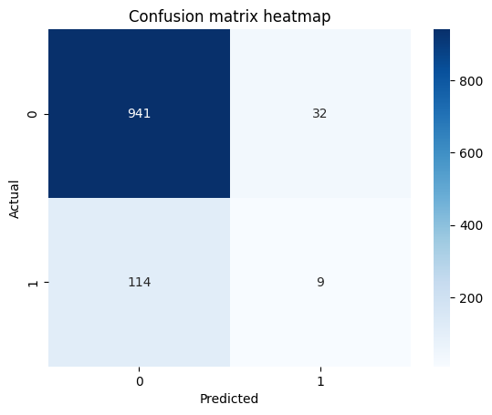

```python
#show confusion matrix for the predicted values
cm = confusion_matrix(y_test,y_pred)
sns.heatmap(cm, annot=True, cmap='Blues', fmt='g')
plt.xlabel('Predicted')
plt.ylabel('Actual')
plt.title('Confusion matrix heatmap')
plt.show()
```

```python
print("the accuracy of the model is ", round(accuracy_score(y_test, y_pred) * 100, 2), "%")
```

```
the accuracy of the model is  86.68 %
```

## Conclusion

The KNN model struggles to correctly predict hypertension cases (class 1), with a significant number of false negatives (114 cases) and false positives (32 cases).

This suggests the model has poor sensitivity.

## Recommendations

- Address Class Imbalance: Consider using techniques like SMOTE (Synthetic Minority Over-sampling Technique) or adjusting class weights to help the model better identify hypertension cases.
- Feature Engineering: Explore additional features or interactions between existing features, such as combining BMI and glucose levels, which might improve the model’s ability to capture the nuances of hypertension risk.
- Model Tuning: Experiment with different values of k in the KNN model or consider alternative models like decision trees or logistic regression that might handle imbalanced data better.
- Further Analysis: Investigate the relationship between work type and hypertension more closely to see if there are patterns that the model is not capturing effectively.